# Reproducible Research: Peer Assessment 1

```r
library(lattice)
```

## Loading and preprocessing the data

download zip file.

```r
if(!file.exists("getdata-projectfiles-UCI HAR Dataset.zip")) {
        temp <- tempfile()
        download.file("http://d396qusza40orc.cloudfront.net/repdata%2Fdata%2Factivity.zip",temp)
        unzip(temp)
        unlink(temp)
}


activity <- read.csv("activity.csv",header = TRUE)
```

## What is mean total number of steps taken per day?

sum steps by days , generate histogram and calculare mean and median

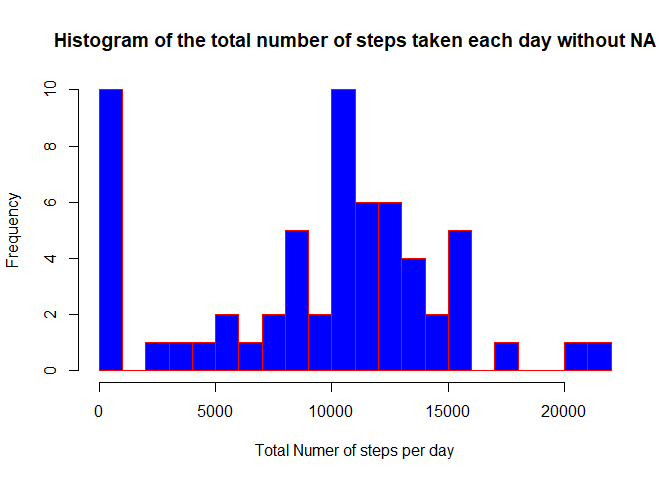

```r
activitypeday <-  aggregate(activity$steps, by=list(activity$date),sum,na.rm = TRUE)

colnames(activitypeday) <- c("date","totalactivityperday")

hist(activitypeday$totalactivityperday,main="Histogram of the total number of steps taken each day without NA",
     xlab="Total Numer of steps per day",
     col="blue",
     border = "red",
     breaks = 20)
```

Calcualte mean and median of activity per day.

The mean is 9354.2295082 and median is 10395.

## What is the average daily activity pattern?

calculate avarage steps per interval. Plot timeseries avarage number of steps per day by interval. Find interval with most avarage steps.

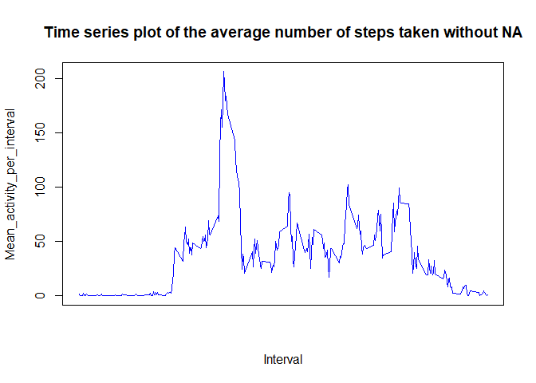

```r
meanactivityperinterval <- aggregate(activity$steps,by=list(activity$interval),mean,na.rm=TRUE)

colnames(meanactivityperinterval) <- c("Interval","Mean_activity_per_interval")


plot(meanactivityperinterval$Interval,meanactivityperinterval$Mean_activity_per_interval,
     xaxt="n",type="l",
     col="blue",
     main="Time series plot of the average number of steps taken without NA",
     xlab="Interval",
     ylab = "Mean_activity_per_interval")
```

Calcualte max activity per interval.

The 5-minute interval, on average across all the days in the dataset, contains the maximum number of steps 835, 206.1698113.

## Imputing missing values

calculate total number of missing value in dataset.

Total number of missing value 2304.

```r
newactivity <- transform(activity,steps = ifelse(is.na(activity$steps),mean(activity$steps,na.rm=TRUE),activity$steps))

newactivityperday <- aggregate(activity$steps,by=list(newactivity$date),sum)

colnames(newactivityperday) <- c("date","activity")
```

Plot histogram of total number of steps taken each day.

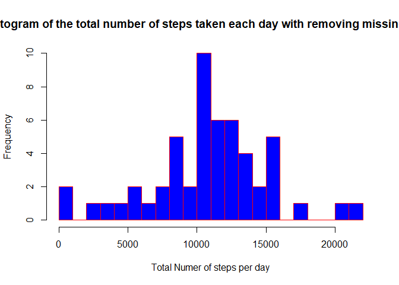

```r
hist(newactivityperday$activity,main="Histogram of the total number of steps taken each day with removing missing value",
     xlab="Total Numer of steps per day",
     col="blue",
     border = "red",
     breaks = 20)
```

Calculate mean and median value for Imputed dataset.

## Are there differences in activity patterns between weekdays and weekends?

Create new factor variable weekday and weekend based on date.

```r
newactivity$day <- factor(weekdays(as.Date(newactivity$date)))

newactivity$wday <- factor(ifelse(newactivity$day  %in% c("Saturday","Sunday"),"Weekend","Weekday"))

meannewactivityperday <- aggregate(newactivity$steps,by=list(newactivity$interval,newactivity$wday),mean)

colnames(meannewactivityperday) <- c("interval","wday","Number_of_Steps")
```

Make a panel plot containing time series plot.

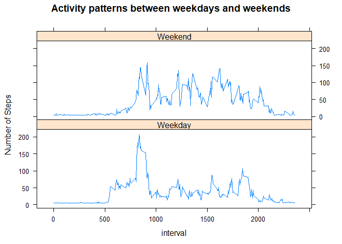

```r
xyplot(Number_of_Steps~interval|wday,meannewactivityperday,type="l",layout=c(1,2),
       ylab = "Number of Steps",
       main = "Activity patterns between weekdays and weekends")
```